# Association Rules - Sales of books

Let’s see what an association rule exactly looks like. It consists of an antecedent and a consequent, both of which are a list of items. Note that implication here is co-occurrence and not causality. For a given rule, itemset is the list of all the items in the antecedent and the consequent.

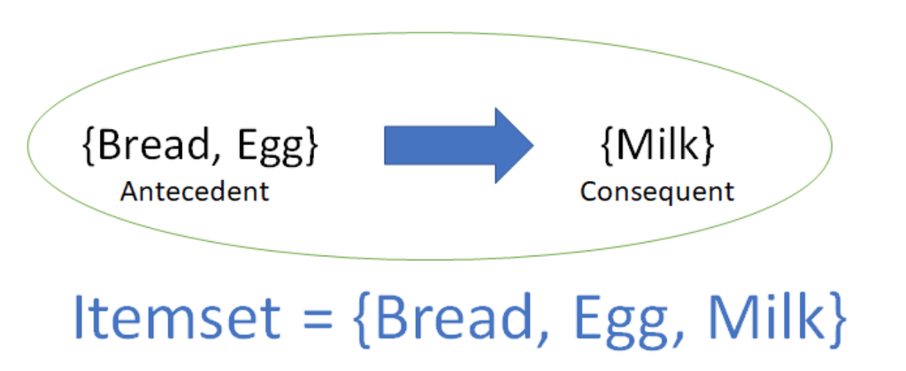

### 1. Support

This measure gives an idea of how frequent an itemset is in all the transactions. Consider itemset1 = {bread} and itemset2 = {shampoo}. There will be far more transactions containing bread than those containing shampoo. So as you rightly guessed, itemset1 will generally have a higher support than itemset2. Now consider itemset1 = {bread, butter} and itemset2 = {bread, shampoo}. Many transactions will have both bread and butter on the cart but bread and shampoo? Not so much. So in this case, itemset1 will generally have a higher support than itemset2. Mathematically, support is the fraction of the total number of transactions in which the itemset occurs.

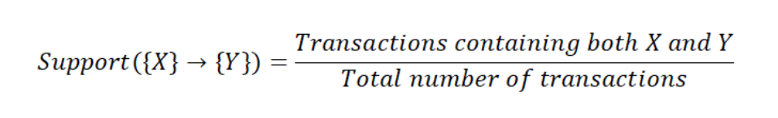

Value of support helps us identify the rules worth considering for further analysis. For example, one might want to consider only the itemsets which occur at least 50 times out of a total of 10,000 transactions i.e. support = 0.005. If an itemset happens to have a very low support, we do not have enough information on the relationship between its items and hence no conclusions can be drawn from such a rule.

### 2. Confidence

This measure defines the likeliness of occurrence of consequent on the cart given that the cart already has the antecedents. That is to answer the question — of all the transactions containing say, {Captain Crunch}, how many also had {Milk} on them? We can say by common knowledge that {Captain Crunch} → {Milk} should be a high confidence rule. Technically, confidence is the conditional probability of occurrence of consequent given the antecedent.

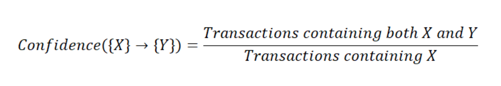

Let us consider few more examples before moving ahead. What do you think would be the confidence for {Butter} → {Bread}? That is, what fraction of transactions having butter also had bread? Very high i.e. a value close to 1? That’s right. What about {Yogurt} → {Milk}? High again. {Toothbrush} → {Milk}? Not so sure? Confidence for this rule will also be high since {Milk} is such a frequent itemset and would be present in every other transaction.

**It does not matter what you have in the antecedent for such a frequent consequent. The confidence for an association rule having a very frequent consequent will always be high.**

Consider the numbers from the figure. Confidence for {Toothbrush} → {Milk} will be 10/(10+4) = 0.7

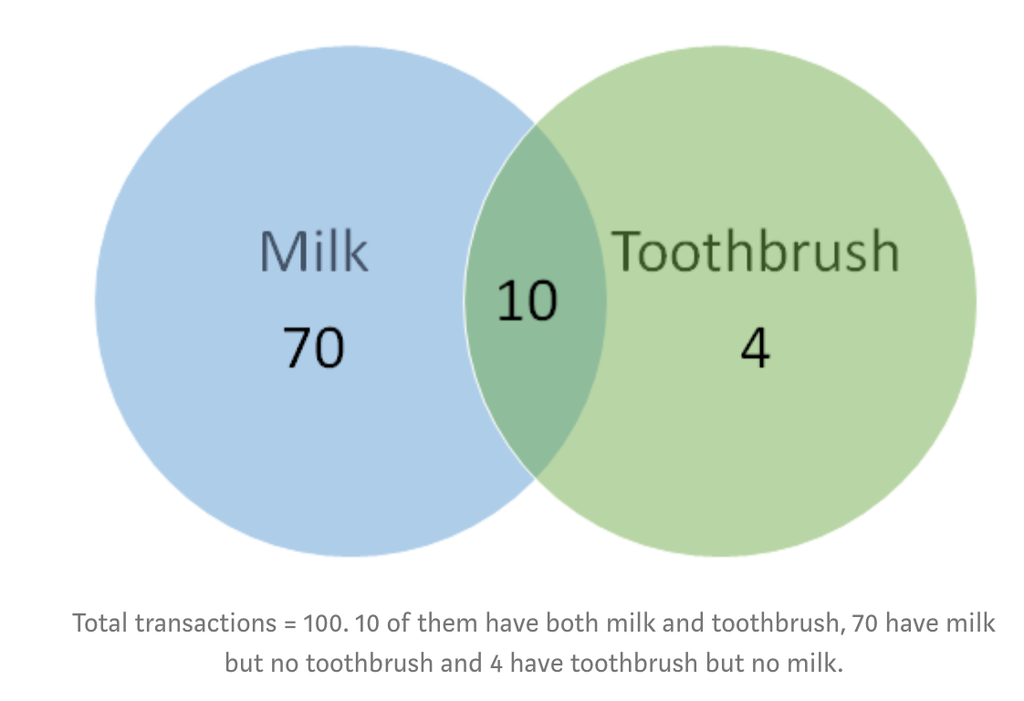

Looks like a high confidence value. But we know intuitively that these two products have a weak association and there is something misleading about this high confidence value. Lift is introduced to overcome this challenge.

*Considering just the value of confidence limits our capability to make any business inference.*

### 3. Lift

Lift controls the support (frequency) of consequent while calculating the conditional probability of occurrence of {Y} given {X}. Lift is a very literal term given to this measure. Think of it as the *lift* that {X} provides to our confidence for having {Y} on the cart. To rephrase, lift is the rise in probability of having {Y} on the cart with the knowledge of {X} being present over the probability of having {Y} on the cart without any knowledge about presence of {X}. Mathematically,

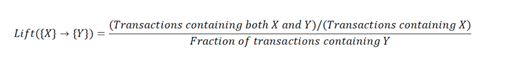

In cases where {X} actually leads to {Y} on the cart, value of lift will be greater than 1. Let us understand this with an example which will be continuation of the {Toothbrush} → {Milk} rule. Probability of having milk on the cart with the knowledge that toothbrush is present (i.e. confidence) : 10/(10+4) = 0.7

Now to put this number in perspective, consider the probability of having milk on the cart without any knowledge about toothbrush: 80/100 = 0.8

These numbers show that having toothbrush on the cart actually reduces the probability of having milk on the cart to 0.7 from 0.8! This will be a lift of 0.7/0.8 = 0.87. Now that’s more like the real picture. A value of lift less than 1 shows that having toothbrush on the cart does not increase the chances of occurrence of milk on the cart in spite of the rule showing a high confidence value. A value of lift greater than 1 vouches for high association between {Y} and {X}. More the value of lift, greater are the chances of preference to buy {Y} if the customer has already bought {X}. Lift is the measure that will help store managers to decide product placements on aisle.

### To recap :

- **Association Rule**: Ex. {X → Y} is a representation of finding Y on the basket which has X on it
- **Itemset**: Ex. {X,Y} is a representation of the list of all items which form the association rule
- **Support**: Fraction of transactions containing the itemset
- **Confidence**: Probability of occurrence of {Y} given {X} is present
- **Lift**: Ratio of confidence to baseline probability of occurrence of {Y}

## Association Rule Mining

Now that we understand how to quantify the importance of association of products within an itemset, the next step is to generate rules from the entire list of items and identify the most important ones. This is not as simple as it might sound. Supermarkets will have thousands of different products in store. After some simple calculations, it can be shown that just 10 products will lead to 57000 rules!! And this number increases exponentially with the increase in number of items. Finding lift values for each of these will get computationally very very expensive. How to deal with this problem? How to come up with a set of most important association rules to be considered? Apriori algorithm comes to our rescue for this.

### 1. Generating itemsets from a list of items

First step in generation of association rules is to get all the frequent itemsets on which binary partitions can be performed to get the antecedent and the consequent. For example, if there are 6 items {Bread, Butter, Egg, Milk, Notebook, Toothbrush} on all the transactions combined, itemsets will look like {Bread}, {Butter}, {Bread, Notebook}, {Milk, Toothbrush}, {Milk, Egg, Vegetables} etc. Size of an itemset can vary from one to the total number of items that we have. Now, we seek only frequent itemsets from this and not all so as to put a check on the number of total itemsets generated.

**Frequent itemsets are the ones which occur at least a minimum number of times in the transactions.** Technically, these are the itemsets for which support value (fraction of transactions containing the itemset) is above a minimum threshold — **minsup**.

A brute force approach to find frequent itemsets is to form all possible itemsets and check the support value of each of these. *Apriori principle* helps in making this search efficient. It states that:

### Apriori principle:

### *All subsets of a frequent itemset must also be frequent.*

This is equivalent to saying that number of transactions containing items {Bread, Egg} is greater than or equal to number of transactions containing {Bread, Egg, Vegetables}. If the latter occurs in 30 transactions, former is occurring in all 30 of them and possibly will occur in even some more transactions. So if support value of {Bread, Egg, Vegetables} (30/100) = 0.3 is above minsup, then we can be assured that support value of {Bread, Egg} i.e. (>30/100) = >0.3 is above minsup too. This is called the **anti-monotone property of support** where if we drop out an item from an itemset, support value of new itemset generated will either be the same or will increase.

### *Apriori principle is a result of anti-monotone property of support.*

Apriori principle allows us to prune all the supersets of an itemset which does not satisfy the minimum threshold condition for support. For example, if {Milk, Notebook} does not satisfy our threshold of minsup, an itemset with any item added to this will never cross the threshold too.

The methodology that results is called *the apriori algorithm*. Steps involved are:

Generate all frequent itemsets (support ≥ minsup) having only one item. Next, generate itemsets of length 2 as all possible combinations of above itemsets. Then, prune the ones for which support value fell below minsup.

Now generate itemsets of length 3 as all possible combinations of length 2 itemsets (that remained after pruning) and perform the same check on support value.

We keep increasing the length of itemsets by one like this and check for the threshold at each step. Pruning of infrequent itemsets reduces the number of itemsets to be considered by more than half! This proportion of reduction in computational power becomes more and more significant as the number of items increases.

This proportion also depends on the minimum support threshold (minsup) that we pick up which is completely subjective to the problem at hand and can be based on past experience.

### 2. Generating all possible rules from the frequent itemsets

Once the frequent itemsets are generated, identifying rules out of them is comparatively less taxing. Rules are formed by binary partition of each itemset. If {Bread,Egg,Milk,Butter} is the frequent itemset, candidate rules will look like:

(Egg, Milk, Butter → Bread), (Bread, Milk, Butter → Egg), (Bread, Egg → Milk, Butter), (Egg, Milk → Bread, Butter), (Butter→ Bread, Egg, Milk)

From a list of all possible candidate rules, we aim to identify rules that fall above a minimum confidence level (**minconf**). Just like the anti-monotone property of support, confidence of rules generated from the same itemset also follows an anti-monotone property. It is anti-monotone with respect to the number of elements in consequent.

This means that confidence of (A,B,C→ D) ≥ (B,C → A,D) ≥ (C → A,B,D). To remind, confidence for {X → Y} = support of {X,Y}/support of {X}

We can see that support of all the rules generated from same itemset remains the same and the difference occurs only in the denominator calculation of confidence. As number of items in X decrease, support{X} increases (as follows from the anti-monotone property of support) and hence the confidence value decreases.

An intuitive explanation for the above will be as follows. Consider F1 and F2:

F1 = fraction of transactions having (butter) also having (egg, milk, bread)

There will be many transactions having butter and all three of egg, milk and bread will be able to find place only in a small number of those.

F2 = fraction of transactions having (milk, butter, bread) also having (egg)

There will only be a handful of transactions having all three of milk, butter and bread (as compared to having just butter) and there will be high chances of having egg on those.

So it will be observed that F1 < F2. Using this property of confidence, pruning is done in a similar way as was done while looking for frequent itemsets. It is illustrated in the figure below.

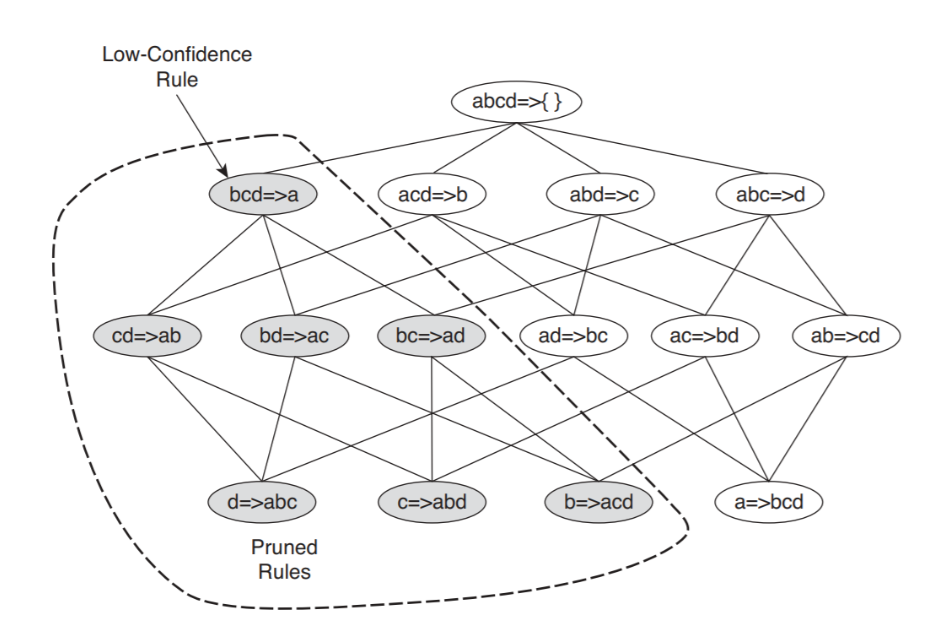

We start with a frequent itemset {a,b,c,d} and start forming rules with just one consequent. Remove the rules failing to satisfy the minconf condition. Now, start forming rules using a combination of consequents from the remaining ones. Keep repeating until only one item is left on antecedent. This process has to be done for all frequent itemsets.

Here again, minimum confidence threshold that we pick up is completely subjective to the problem at hand.

With these two steps, we have identified a set of association rules which satisfy both the minimum support and minimum confidence condition. The number of such rules obtained will vary with the values of *minsup* and *minconf.* **Now, this subset of rules thus generated can be searched for highest values of lift to make business decisions.** There are some nicely built libraries in R to fetch association rules from transactions by putting in minsup and minconf as parameters. They also provide capabilities to visualize the same.

**Maximal frequent itemset**: It is a frequent itemset for which none of the immediate supersets are frequent. This is like a frequent itemset X to which no item y can be added such that {X,y} still remains above minsup threshold.

## Step 1: Reading in the data

You can read zipped files into R without unzipping or downloading the file from the web in advance. Use the gz(), bz(), unz(), or url() commands. For example:

`zz=gzfile('file.csv.gz','rt')`

`dat=read.csv(zz,header=F)`

```r
bookbaskets <- read.transactions("bookdata.tsv.gz",
                                 format="single",
                                 sep="\t",
                                 cols=c("userid", "title"),
                                 rm.duplicates=T,
                                 header=TRUE)
```

## Step 2: Examining the data

The object is of class transactions:

```r
class(bookbaskets)
```

```
## [1] "transactions"
## attr(,"package")
## [1] "arules"
```

Printing the object tells you its dimensions:

```r
bookbaskets
```

```
## transactions in sparse format with
##  92108 transactions (rows) and
##  220447 items (columns)
```

Also, `dim` can be used:

```r
dim(bookbaskets)
```

```
## [1]  92108 220447
```

The columns are labeled by book title: (The transactions for Arules algorithm are organized as a sparse matrix: columns are book titles, rows are customers’ ids. The binary 0/1 designate their basket choices.)

```r
colnames(bookbaskets)[1:5]
```

```
## [1] " A Light in the Storm: The Civil War Diary of Amelia Martin, Fenwick Island, Delaware, 1861"
## [2] " Always Have Popsicles"
## [3] " Apple Magic"
## [4] " Ask Lily"
## [5] " Beyond IBM: Leadership Marketing and Finance for the 1990s"
```

The rows are labeled by customer:

```r
rownames(bookbaskets)[1:5]
```

```
## [1] "10"     "1000"   "100001" "100002" "100004"
```

You can examine the distribution of transaction sizes (or basket sizes) with the function size():

```r
basketSizes <- size(bookbaskets)
summary(basketSizes)
```

```
##    Min. 1st Qu.  Median    Mean 3rd Qu.    Max.
##     1.0     1.0     1.0    11.1     4.0 10253.0
```

Most customers (at least half of them, in fact) only expressed interest in one book. But someone has expressed interest in more than 10,000! You probably want to look more closely at the size distribution to see what’s going on.

```r
quantile(basketSizes, probs=seq(0,1,0.1))
```

```
##    0%   10%   20%   30%   40%   50%   60%   70%   80%   90%  100%
##     1     1     1     1     1     1     2     3     5    13 10253
```

```r
quantile(basketSizes, probs=c(0.99, 1))
```

```
##   99%  100%
##   179 10253
```

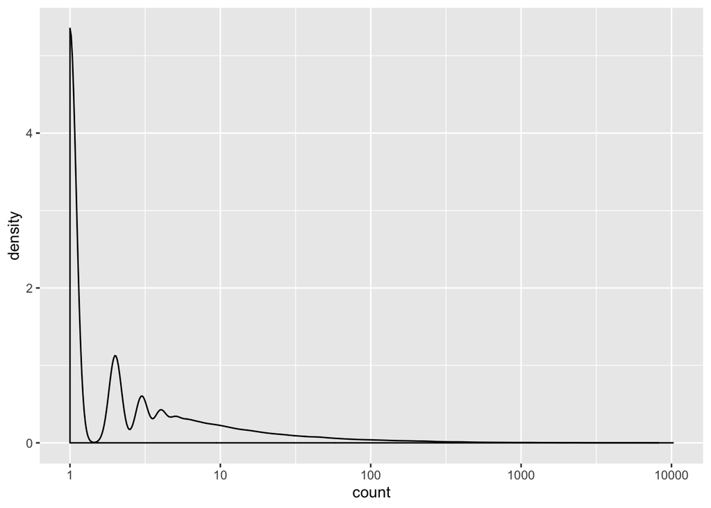

```r
library(ggplot2)
ggplot(data.frame(count=basketSizes)) +
geom_density(aes(x=count), binwidth=1) +
scale_x_log10()
```

Look at the first 5 transactions:

```r
inspect(bookbaskets[1:5])
```

```
##     items                                                                                           transactionID
## [1] {New Vegetarian: Bold and Beautiful Recipes for Every Occasion}                                        10
## [2] {Il Dio Delle Piccole Cose}                                                                            1000
## [3] {Cybernation}                                                                                          100001
## [4] {Lasher: Lives of the Mayfair Witches}                                                                 100002
## [5] {Chicken Soup for the Teenage Soul on Tough Stuff : Stories of Tough Times and Lessons Learned,
##      Dragon Ball Z, Vol. 1,
##      Harry Potter and the Chamber of Secrets,
##      Harry Potter and the Sorcerer's Stone,
##      Holes,
##      Prey,
##      Primary Colors: A Novel of Politics,
##      Rising Sun,
##      The Cat Who Smelled a Rat,
##      The Fellowship of the Ring,
##      The Hunt for Red October,
##      The Return of the King,
##      The Two Towers}                                                                                       100004
```

Which books are they reading? The function itemFrequency() will give you the relative frequency of each book in the transaction data:

```r
bookFreq <- itemFrequency(bookbaskets)
summary(bookFreq)
```

```
##      Min.   1st Qu.    Median      Mean   3rd Qu.      Max.
## 1.086e-05 1.086e-05 1.086e-05 5.035e-05 3.257e-05 2.716e-02
```

```r
sum(bookFreq)
```

```
## [1] 11.09909
```

Note that the frequencies don’t sum to 1. You can recover the number of times that each book occurred in the data by normalizing the item frequencies and multiplying by the total number of items.

Finding the ten most frequent books:

```r
# Get the absolute count of book occurrences
bookCount <- (bookFreq/sum(bookFreq))*sum(basketSizes)

summary(bookCount)
```

```
##     Min.  1st Qu.   Median     Mean  3rd Qu.     Max.
##    1.000    1.000    1.000    4.638    3.000 2502.000
```

```r
orderedBooks <- sort(bookCount, decreasing = T)
orderedBooks[1:10]
```

```
##                                     Wild Animus
##                                            2502
##                       The Lovely Bones: A Novel
##                                            1295
##                               She's Come Undone
##                                             934
##                               The Da Vinci Code
##                                             905
##           Harry Potter and the Sorcerer's Stone
##                                             832
##                      The Nanny Diaries: A Novel
##                                             821
##                                 A Painted House
##                                             819
##                           Bridget Jones's Diary
##                                             772
##                         The Secret Life of Bees
##                                             762
## Divine Secrets of the Ya-Ya Sisterhood: A Novel
##                                             737
```

The most popular book in the dataset occurred in fewer than 3% of the baskets:

```r
orderedBooks[1]/dim(bookbaskets)[1]
```

```
## Wild Animus
##  0.02716376
```

The last observation in the preceding listing highlights one of the issues with mining high-dimensional data: when you have thousands of variables, or thousands of items, almost every event is rare. Keep this point in mind when deciding on support thresholds for rule mining; your thresholds will often need to be quite low.

Before we get to the rule mining, let’s refine the data a bit more. As we observedearlier, half of the customers in the data only expressed interest in a single book. Since you want to find books that occur together in people’s interest lists, you can’t make any direct use of people who haven’t yet shown interest in multiple books. You can restrict the dataset to customers who have expressed interest in at least two books:

```r
bookbaskets_use <- bookbaskets[basketSizes > 1]
dim(bookbaskets_use)
```

```
## [1]  40822 220447
```

Now you’re ready to look for association rules.

## Step 3. The Apriori() function

In order to mine rules, you need to decide on a minimum support level (**minsup**) and a minimum threshold level (**minconf**). For this example, let’s try restricting the itemsets that we’ll consider to those that are supported by at least 100 people. This leads to a minimum support of 100/dim(bookbaskets_use)[1] = 100/40822. This is about 0.002, or 0.2%. We’ll use a confidence threshold (**minconf**) of 75%.

`minsup = 0.002`

`minconf = 0.75`

### Finding the association rules

```r
rules <- apriori(bookbaskets_use,
parameter =list(support = 0.002, confidence=0.75))
```

```
## Apriori
##
## Parameter specification:
##  confidence minval smax arem  aval originalSupport maxtime support minlen
##        0.75    0.1    1 none FALSE            TRUE       5   0.002      1
##  maxlen target   ext
##      10  rules FALSE
##
## Algorithmic control:
##  filter tree heap memopt load sort verbose
##     0.1 TRUE TRUE  FALSE TRUE    2    TRUE
##
## Absolute minimum support count: 81
##
## set item appearances ...[0 item(s)] done [0.00s].
## set transactions ...[216031 item(s), 40822 transaction(s)] done [1.07s].
## sorting and recoding items ... [1256 item(s)] done [0.04s].
## creating transaction tree ... done [0.02s].
## checking subsets of size 1 2 3 4 5 done [0.05s].
## writing ... [191 rule(s)] done [0.00s].
## creating S4 object  ... done [0.07s].
```

The summary of the apriori() output reports the number of rules found:

```r
summary(rules)
```

```
## set of 191 rules
##
## rule length distribution (lhs + rhs):sizes
##   2   3   4   5
##  11 100  66  14
##
##    Min. 1st Qu.  Median    Mean 3rd Qu.    Max.
##   2.000   3.000   3.000   3.435   4.000   5.000
##
## summary of quality measures:
##     support           confidence          lift            count
##  Min.   :0.002009   Min.   :0.7500   Min.   : 40.89   Min.   : 82.0
##  1st Qu.:0.002131   1st Qu.:0.8113   1st Qu.: 86.44   1st Qu.: 87.0
##  Median :0.002278   Median :0.8468   Median :131.36   Median : 93.0
##  Mean   :0.002593   Mean   :0.8569   Mean   :129.68   Mean   :105.8
##  3rd Qu.:0.002695   3rd Qu.:0.9065   3rd Qu.:158.77   3rd Qu.:110.0
##  Max.   :0.005830   Max.   :0.9882   Max.   :321.89   Max.   :238.0
##
## mining info:
##             data ntransactions support confidence
##  bookbaskets_use         40822   0.002       0.75
```

Most rules contain 3 items : 2 on the left side, X (lhs) and 1 on the right side, Y (rhs).

The quality measures on the rules include not only the rules’ support and confidence, but also a quantity called lift. Lift compares the frequency of an observed pattern with how often you’d expect to see that pattern just by chance. The lift of a rule “if X, then Y” is given by support(union(X, Y))/(support(X)*support(Y)). If the lift is near 1, then there’s a good chance that the pattern you observed is occurring just by chance. The larger the lift, the more likely that the pattern is “real.” In this case, all the discovered rules have a lift of at least 40, so they’re likely to be real patterns in customer behavior.

## Step 4. Inspecting and evaluating rules

There are also other metrics and interest measures you can use to evaluate the rules by using the function interestMeasure(). We’ll look at two of these measures: coverage and fishersExactTest. Coverage is the support of the left side of the rule (X); it tells you how often the rule would be applied in the dataset. Fisher’s exact test is a significance test for whether an observed pattern is real, or chance (the same thing lift measures; Fisher’s test is more formal). Fisher’s exact test returns the p-value, or the probability that you would see the observed pattern by chance; you want the p-value to be small.

```r
measures <- interestMeasure(rules,
                            measure=c("coverage",
                                     "fishersExactTest"),
                            transactions=bookbaskets_use)
summary(measures)
```

```
##     coverage        fishersExactTest
##  Min.   :0.002082   Min.   : 0.000e+00
##  1st Qu.:0.002511   1st Qu.: 0.000e+00
##  Median :0.002719   Median : 0.000e+00
##  Mean   :0.003039   Mean   :5.080e-138
##  3rd Qu.:0.003160   3rd Qu.: 0.000e+00
##  Max.   :0.006982   Max.   :9.702e-136
```

The call to interestMeasure() takes as arguments the discovered rules, a list of interest measures to apply, and a dataset to evaluate the interest measures over. This is usually the same set used to mine the rules, but it needn’t be. For instance, you can evaluate the rules over the full dataset, bookbaskets, to get coverage estimates that reflect all the customers, not just the ones who showed interest in more than one book.

The coverage of the discovered rules ranges from 0.002–0.007, equivalent to a range of about 100–250 people. All the p-values from Fisher’s test are small, so it’s likely that the rules reflect actual customer behavior patterns.

You can also call interestMeasure() with methods support, confidence, and lift, among others. This would be useful in our example if you wanted to get support, confidence, and lift estimates for the full dataset bookbaskets, rather than the filtered dataset bookbaskets_use—or for a subset of the data, for instance, only customers from the United States.

The function inspect() pretty-prints the rules. The function sort() allows you to sort the rules by a quality or interest measure, like confidence. To print the five most confident rules in the dataset, you could use the following command:

```r
inspect(head((sort(rules, by="confidence")), n=5))
```

```
##     lhs                                               rhs                                                support confidence      lift count
## [1] {Four to Score,
##      High Five,
##      Seven Up,
##      Two for the Dough}                            => {Three To Get Deadly : A Stephanie Plum Novel} 0.002057714  0.9882353 165.33500    84
## [2] {Harry Potter and the Order of the Phoenix,
##      Harry Potter and the Prisoner of Azkaban,
##      Harry Potter and the Sorcerer's Stone}        => {Harry Potter and the Chamber of Secrets}      0.002866102  0.9669421  72.82751   117
## [3] {Four to Score,
##      High Five,
##      One for the Money,
##      Two for the Dough}                            => {Three To Get Deadly : A Stephanie Plum Novel} 0.002082211  0.9659091 161.59976    85
## [4] {Four to Score,
##      Seven Up,
##      Three To Get Deadly : A Stephanie Plum Novel,
##      Two for the Dough}                            => {High Five}                                    0.002057714  0.9655172 180.79975    84
## [5] {High Five,
##      Seven Up,
##      Three To Get Deadly : A Stephanie Plum Novel,
##      Two for the Dough}                            => {Four to Score}                                0.002057714  0.9655172 167.72062    84
```

The second thing to notice is that rules 1, 4, and 5 are permutations of the same itemset. This is likely to happen when the rules get long.

### Restricting which items to mine

You can restrict which items appear in the left side or right side of a rule. Suppose you’re interested specifically in books that tend to co-occur with the novel *The Lovely Bones*. You can do this by restricting which books appear on the right side of the rule, using the *appearance* parameter.

Relax the *minsup* to 0.001 and *minconf* to 0.6:

```r
brules <- apriori(bookbaskets_use,
                  parameter =list(support = 0.001,
                                  confidence=0.6),
                  appearance=list(rhs=c("The Lovely Bones: A Novel"),
                                  default="lhs"))
```

```
## Apriori
##
## Parameter specification:
##  confidence minval smax arem  aval originalSupport maxtime support minlen
##         0.6    0.1    1 none FALSE            TRUE       5   0.001      1
##  maxlen target   ext
##      10  rules FALSE
##
## Algorithmic control:
##  filter tree heap memopt load sort verbose
##     0.1 TRUE TRUE  FALSE TRUE    2    TRUE
##
## Absolute minimum support count: 40
##
## set item appearances ...[1 item(s)] done [0.00s].
## set transactions ...[216031 item(s), 40822 transaction(s)] done [1.03s].
## sorting and recoding items ... [3172 item(s)] done [0.04s].
## creating transaction tree ... done [0.02s].
## checking subsets of size 1 2 3 4 5 6 7 8 done [0.26s].
## writing ... [46 rule(s)] done [0.05s].
## creating S4 object  ... done [0.07s].
```

```r
summary(brules)
```

```
## set of 46 rules
##
## rule length distribution (lhs + rhs):sizes
##  3  4
## 44  2
##
##    Min. 1st Qu.  Median    Mean 3rd Qu.    Max.
##   3.000   3.000   3.000   3.043   3.000   4.000
##
## summary of quality measures:
##     support           confidence          lift           count
##  Min.   :0.001004   Min.   :0.6000   Min.   :21.81   Min.   :41.00
##  1st Qu.:0.001029   1st Qu.:0.6118   1st Qu.:22.24   1st Qu.:42.00
##  Median :0.001102   Median :0.6258   Median :22.75   Median :45.00
##  Mean   :0.001132   Mean   :0.6365   Mean   :23.14   Mean   :46.22
##  3rd Qu.:0.001219   3rd Qu.:0.6457   3rd Qu.:23.47   3rd Qu.:49.75
##  Max.   :0.001396   Max.   :0.7455   Max.   :27.10   Max.   :57.00
##
## mining info:
##             data ntransactions support confidence
##  bookbaskets_use         40822   0.001        0.6
```

The supports, confidences, and lifts are lower than they were in our previous example, but the lifts are still much greater than 1, so it’s likely that the rules reflect real customer behavior patterns.

Let’s inspect the rules, sorted by confidence. Since they’ll all have the same right side, you can use the lhs() function to only look at the left sides.

```r
brulesConf <- sort(brules, by="confidence")
inspect(head(lhs(brulesConf), n=5))
```

```
##     items
## [1] {Divine Secrets of the Ya-Ya Sisterhood: A Novel,
##      Lucky : A Memoir}
## [2] {Lucky : A Memoir,
##      The Notebook}
## [3] {Lucky : A Memoir,
##      Wild Animus}
## [4] {Midwives: A Novel,
##      Wicked: The Life and Times of the Wicked Witch of the West}
## [5] {Lucky : A Memoir,
##      Summer Sisters}
```

Note that four of the five most confident rules include Lucky: A Memoir in the left side, which perhaps isn’t surprising, since Lucky was written by the author of The Lovely Bones. Suppose you want to find out about works by other authors that are interesting to people who showed interest in The Lovely Bones; you can use subset() to filter down to only rules that don’t include Lucky.

```r
brulesSub <- subset(brules, subset=!(lhs %in% "Lucky : A Memoir"))
brulesConf <- sort(brulesSub, by="confidence")
inspect(head(lhs(brulesConf), n=5))
```

```
##     items
## [1] {Midwives: A Novel,
##      Wicked: The Life and Times of the Wicked Witch of the West}
## [2] {She's Come Undone,
##      The Secret Life of Bees,
##      Wild Animus}
## [3] {A Walk to Remember,
##      The Nanny Diaries: A Novel}
## [4] {Beloved,
##      The Red Tent}
## [5] {The Da Vinci Code,
##      The Reader}
```

These examples show that association rule mining is often highly interactive. To get interesting rules, you must often set the support and confidence levels fairly low; as a result you can get many, many rules. Some rules will be more interesting or surprising to you than others; to find them requires sorting the rules by different interest measures, or perhaps restricting yourself to specific subsets of rules.

## Association rule takeaways

Here’s what you should remember about association rules: - The goal of association rule mining is to find relationships in the data: items or attributes that tend to occur together. - A good rule “if X, then Y” should occur more often than you’d expect to observe by chance. You can use lift or Fisher’s exact test to check if this is true. - When a large number of different possible items can be in a basket (in our example, thousands of different books), most events will be rare (have low support). - Association rule mining is often interactive, as there can be many rules to sort and sift through.

## Step 5. Visalisation

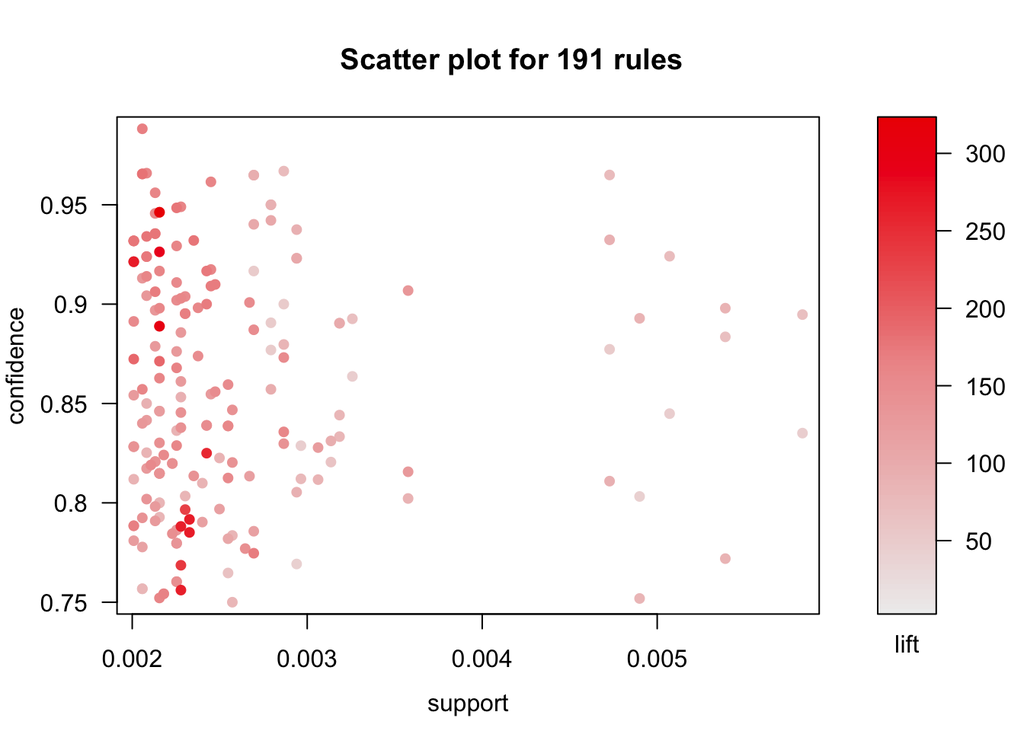

```r
library(grid)
library(arulesViz)
plot(rules, jitter=0)
```

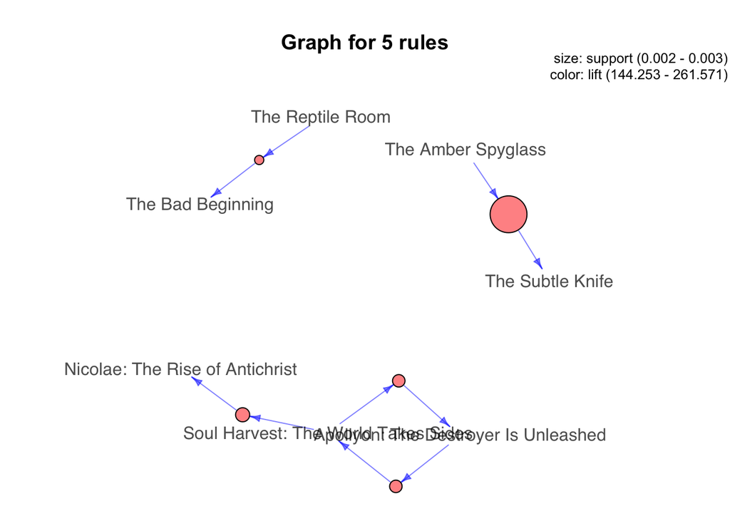

```r
plot(rules[1:5], method="graph", control=list(nodeCol="red", edgeCol="blue"))
```

Inspect the rules:

```r
inspect(sort(rules, by = "lift")[1:10])
```

```
##      lhs                                                               rhs                                        support confidence     lift count
## [1]  {Key of Light,
##       Key of Valor}                                                 => {Key of Knowledge}                     0.002155700  0.9462366 321.8939    88
## [2]  {Key of Knowledge,
##       Key of Light}                                                 => {Key of Valor}                         0.002155700  0.8888889 299.8861    88
## [3]  {Key of Knowledge,
##       Key of Valor}                                                 => {Key of Light}                         0.002155700  0.9263158 284.3163    88
## [4]  {Key of Valor}                                                 => {Key of Knowledge}                     0.002327177  0.7851240 267.0861    95
## [5]  {Key of Knowledge}                                             => {Key of Valor}                         0.002327177  0.7916667 267.0861    95
## [6]  {Soul Harvest: The World Takes Sides,
##       Tribulation Force: The Continuing Drama of Those Left Behind} => {Nicolae: The Rise of Antichrist}      0.002008721  0.9213483 264.8682    82
## [7]  {Apollyon: The Destroyer Is Unleashed}                         => {Soul Harvest: The World Takes Sides}  0.002278183  0.7560976 261.5713    93
## [8]  {Soul Harvest: The World Takes Sides}                          => {Apollyon: The Destroyer Is Unleashed} 0.002278183  0.7881356 261.5713    93
## [9]  {Key of Knowledge}                                             => {Key of Light}                         0.002425163  0.8250000 253.2192    99
## [10] {Key of Valor}                                                 => {Key of Light}                         0.002278183  0.7685950 235.9067    93
```

Find a subset of rules with Harry Potter book:

```r
# %pin% - partial matching

harryrules <- subset(rules, subset = lhs %in% "Harry Potter and the Sorcerer's Stone" )
inspect(harryrules[1:5])
```

```
##     lhs                                            rhs                                            support confidence     lift count
## [1] {Harry Potter and the Order of the Phoenix,
##      Harry Potter and the Sorcerer's Stone}     => {Harry Potter and the Goblet of Fire}      0.002939591  0.8053691 88.61665   120
## [2] {Harry Potter and the Order of the Phoenix,
##      Harry Potter and the Sorcerer's Stone}     => {Harry Potter and the Prisoner of Azkaban} 0.002964088  0.8120805 77.27448   121
## [3] {Harry Potter and the Order of the Phoenix,
##      Harry Potter and the Sorcerer's Stone}     => {Harry Potter and the Chamber of Secrets}  0.003258047  0.8926174 67.22957   133
## [4] {Harry Potter and the Goblet of Fire,
##      Harry Potter and the Sorcerer's Stone}     => {Harry Potter and the Prisoner of Azkaban} 0.004899319  0.8928571 84.96087   200
## [5] {Harry Potter and the Prisoner of Azkaban,
##      Harry Potter and the Sorcerer's Stone}     => {Harry Potter and the Goblet of Fire}      0.004899319  0.7518797 82.73109   200
```

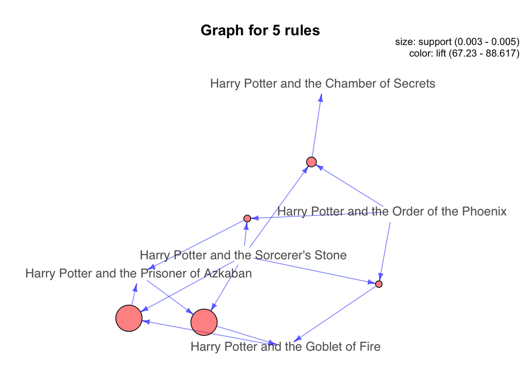

```r
plot(harryrules[1:5], method="graph", control=list(nodeCol="red", edgeCol="blue"))
```

Save rules in a CSV file:

```r
write(rules, file = "Bookrules.csv", sep = ",", quote = TRUE, row.names = FALSE)
```